# Meeting_Notebook

```python
# Chunk 1: Load a single snapshot from your real game data
import os
import pandas as pd
path = "C:\\Users\\zaneh\\OneDrive\\\Documents\\York_PhD\\Order_Book\\playoff_data"
paths = [os.path.join(path, i) for i in os.listdir(path)]
filtered_paths = paths[:16] + paths[18:]

# Adjust this to point to your actual Parquet file path
df = pd.read_parquet(filtered_paths[0])

# Convert Timestamp column if needed
df['Timestamp'] = pd.to_datetime(df['Timestamp'])

# Pick a single snapshot — earliest time in file
snapshot_time = df['Timestamp'].unique()[int(len(df['Timestamp'].unique())/5)]
snapshot = df[df['Timestamp'] == snapshot_time].copy()
snapshot = snapshot.groupby(['Price','Side', 'Timestamp']).sum()
# Preview the snapshot
snapshot = snapshot.reset_index()
# snapshot = snapshot.reset_index()
snapshot = snapshot[['Price', 'Size', 'Side', 'Timestamp']].sort_values(by='Price').reset_index().drop('index', axis = 1)
subsnap = snapshot[15:35]
subsnap
```

|  | Price | Size | Side | Timestamp |
| --- | --- | --- | --- | --- |
| 15 | 0.68 | 10.00 | bid | 2025-04-29 15:46:01.344 |
| 16 | 0.69 | 38.98 | bid | 2025-04-29 15:46:01.344 |
| 17 | 0.70 | 49858.56 | bid | 2025-04-29 15:46:01.344 |
| 18 | 0.71 | 35290.00 | bid | 2025-04-29 15:46:01.344 |
| 19 | 0.72 | 4110.00 | bid | 2025-04-29 15:46:01.344 |
| 20 | 0.73 | 37390.00 | bid | 2025-04-29 15:46:01.344 |
| 21 | 0.74 | 170048.54 | bid | 2025-04-29 15:46:01.344 |
| 22 | 0.75 | 147453.47 | bid | 2025-04-29 15:46:01.344 |
| 23 | 0.76 | 37942.96 | bid | 2025-04-29 15:46:01.344 |
| 24 | 0.77 | 43468.82 | ask | 2025-04-29 15:46:01.344 |
| 25 | 0.78 | 80479.73 | ask | 2025-04-29 15:46:01.344 |
| 26 | 0.79 | 42016.80 | ask | 2025-04-29 15:46:01.344 |
| 27 | 0.80 | 8260.00 | ask | 2025-04-29 15:46:01.344 |
| 28 | 0.81 | 30985.26 | ask | 2025-04-29 15:46:01.344 |
| 29 | 0.82 | 80.00 | ask | 2025-04-29 15:46:01.344 |
| 30 | 0.83 | 35280.00 | ask | 2025-04-29 15:46:01.344 |
| 31 | 0.84 | 76560.00 | ask | 2025-04-29 15:46:01.344 |
| 32 | 0.89 | 400.00 | ask | 2025-04-29 15:46:01.344 |
| 33 | 0.91 | 147860.00 | ask | 2025-04-29 15:46:01.344 |
| 34 | 0.93 | 300.00 | ask | 2025-04-29 15:46:01.344 |

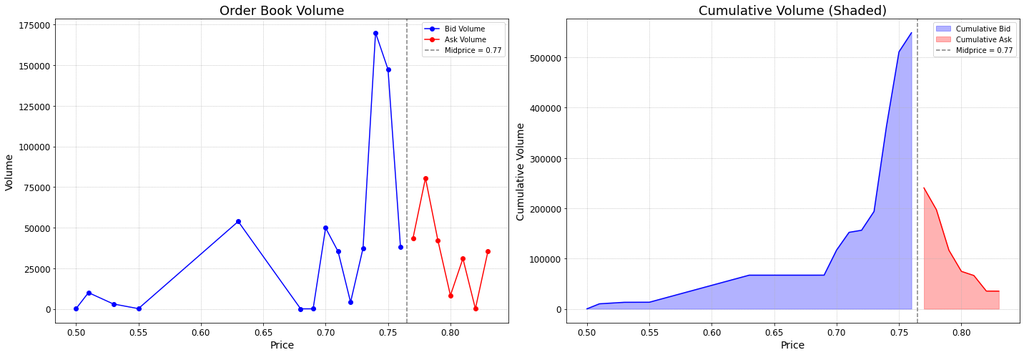

```python
import matplotlib.pyplot as plt

# Filter and sort
plots = snapshot[10:-10].copy()
bids = plots.query("Side == 'bid'").sort_values(by='Price')
asks = plots.query("Side == 'ask'").sort_values(by='Price')

# Cumulative volume
bids['Cumulative'] = bids['Size'].cumsum()
asks['Cumulative'] = asks['Size'][::-1].cumsum()[::-1]  # descending

# Midprice
midprice = snapshot.query("Side == 'bid'")['Price'].max() + snapshot.query("Side == 'ask'")['Price'].min()
midprice /= 2

# Subplots
fig, (ax1, ax2) = plt.subplots(1, 2, figsize=(20, 7), facecolor='white')

# --- Subplot 1: Volume ---
ax1.plot(bids['Price'], bids['Size'], marker='o', linestyle='-', color='blue', label='Bid Volume')
ax1.plot(asks['Price'], asks['Size'], marker='o', linestyle='-', color='red', label='Ask Volume')
ax1.axvline(midprice, color='gray', linestyle='--', label=f'Midprice = {midprice:.2f}')
ax1.set_title("Order Book Volume", fontsize=18)
ax1.set_xlabel("Price", fontsize=14)
ax1.set_ylabel("Volume", fontsize=14)
ax1.grid(True, linestyle=':')
ax1.legend()
ax1.tick_params(labelsize=12)

# --- Subplot 2: Cumulative Volume with Fill ---
ax2.fill_between(bids['Price'], 0, bids['Cumulative'], color='blue', alpha=0.3, label='Cumulative Bid')
ax2.plot(bids['Price'], bids['Cumulative'], color='blue')

ax2.fill_between(asks['Price'], 0, asks['Cumulative'], color='red', alpha=0.3, label='Cumulative Ask')
ax2.plot(asks['Price'], asks['Cumulative'], color='red')

ax2.axvline(midprice, color='gray', linestyle='--', label=f'Midprice = {midprice:.2f}')
ax2.set_title("Cumulative Volume (Shaded)", fontsize=18)
ax2.set_xlabel("Price", fontsize=14)
ax2.set_ylabel("Cumulative Volume", fontsize=14)
ax2.grid(True, linestyle=':')
ax2.legend()
ax2.tick_params(labelsize=12)

plt.tight_layout()
plt.show()
```

## Project Goal

We develop a Bayesian model to infer the latent belief distribution of traders in a prediction market using only snapshots of the standing limit order book. By modeling observed volume at each price as a Gamma-distributed function of belief mass and distance from the midprice, we recover the underlying distribution of trader beliefs without relying on order flow or trade data.

## Stronger Punchline with Formal Examples

This model recovers latent market structure from observable book shape and provides formal, interpretable outputs that can be used to analyze market dynamics. After Bayesian inference:

- The posterior over $ \mu_t $ yields a **continuous estimate of the market-implied probability** at time $ t $. Unlike midprice or VWAP, it reflects the full distribution of standing liquidity.

  **Example**: In a high-liquidity Polymarket contract on a U.S. election, $ \mu_t $ shifts from 0.42 to 0.51 following a key debate. This movement reflects a change in the belief-weighted depth of the market, not just a best bid/ask flinch.
- The posterior over $ \nu_t $ allows us to distinguish between **high-consensus markets** (tight book around a single belief) and **dispersed or adversarial markets** (liquidity spread across conflicting price regions).

  **Example**: For an obscure geopolitical question, $ \mu_t = 0.47 $ but $ \nu_t \approx 2.5 $, indicating wide disagreement among traders despite a stable midprice. This identifies cases where the market price is not representative of strong consensus.
- By tracking $ (\mu_t, \nu_t) $ over time, we produce **belief dynamics**, enabling real-time monitoring of how markets digest information.

This gives a principled, interpretable way to extract meaningful belief summaries from order book data alone, without relying on message data, market maker assumptions, or agent-based simulations.

## Bayesian Inference of Belief Distributions from Limit Order Books

We model the standing volume $V(p)$ at each discrete price level $p$ in a binary prediction market. At each snapshot in time, we observe the set of active bid and ask orders and their associated sizes.

We assume that traders have probabilistic beliefs $b \in [0, 1]$ and place limit orders based on those beliefs. Specifically, a trader will place a bid if $b > p$ and an ask if $b < p$, with volume decaying as $p$ moves further from $b$.

We model the distribution of beliefs with a Beta CDF:

$$ B(p) = \text{CDF}_{\text{Beta}}\left(p;\ \mu \cdot \nu,\ (1 - \mu) \cdot \nu\right) $$

Here, $\mu \in (0,1)$ represents the mean belief, and $\nu > 0$ controls concentration.

We define a shape function $\psi(p)$ for the volume curve:

$$ \psi(p) = \begin{cases} (1 - B(p)) \cdot \exp\left(-\beta(p^* - p)\right) & \text{if } p < p^* \\ B(p) \cdot \exp\left(-\beta(p - p^*)\right) & \text{if } p > p^* \\ 0 & \text{otherwise} \end{cases} $$

where $p^*$ is the midprice and $\beta > 0$ controls how quickly volume decays away from $p^*$.

We assume expected volume is proportional to $\psi(p)$:

$$ \mathbb{E}[V(p)] = \alpha \cdot \psi(p) $$

To model noise and excess variation, we place a Gamma likelihood over $V(p)$:

$$ V(p) \sim \text{Gamma}\left(\kappa(p),\ \gamma\right) \quad \text{where} \quad \kappa(p) = \frac{\alpha \cdot \psi(p)}{\gamma} $$

This yields the log-likelihood:

$$ \log \mathcal{L}(\theta) = \sum_p \left[ (\kappa(p) - 1) \log V(p) - \gamma V(p) - \log \Gamma(\kappa(p)) + \kappa(p) \log \gamma \right] $$

with parameters $\theta = (\alpha, \beta, \mu, \nu, \gamma)$.

We complete the model with priors:

- $ \alpha \sim \text{HalfNormal}(\sigma_\alpha) $
- $ \beta \sim \text{HalfNormal}(\sigma_\beta) $
- $ \mu \sim \text{Beta}(a, b) $
- $ \nu \sim \text{Gamma}(s, r) $
- $ \gamma \sim \text{Gamma}(s', r') $

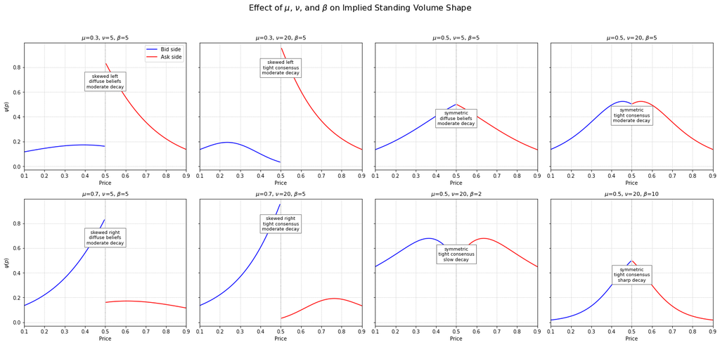

```python
# Updated plot: split bids and asks at the midprice with separate colors and clearer title
import numpy as np
import pandas as pd
import matplotlib.pyplot as plt
from scipy.stats import beta

# Define a grid of parameter choices: each tuple is (mu, nu, beta_param)
param_grid = [
    (0.3, 5, 5),
    (0.3, 20, 5),
    (0.5, 5, 5),
    (0.5, 20, 5),
    (0.7, 5, 5),
    (0.7, 20, 5),
    (0.5, 20, 2),
    (0.5, 20, 10),
]

# Price grid
p_grid = np.linspace(0.1, 0.9, 100)
fig, axes = plt.subplots(2, 4, figsize=(20, 10), sharey=True, facecolor='white')
axes = axes.flatten()

for i, (mu, nu, beta_param) in enumerate(param_grid):
    ax = axes[i]

    Bp = beta.cdf(p_grid, mu * nu, (1 - mu) * nu)
    midprice = 0.5

    psi_bid = np.where(
        p_grid < midprice,
        (1 - Bp) * np.exp(-beta_param * (midprice - p_grid)),
        np.nan
    )
    psi_ask = np.where(
        p_grid > midprice,
        Bp * np.exp(-beta_param * (p_grid - midprice)),
        np.nan
    )

    ax.plot(p_grid, psi_bid, color='blue', label='Bid side')
    ax.plot(p_grid, psi_ask, color='red', label='Ask side')

    ax.axvline(midprice, color='gray', linestyle=':', linewidth=1)

    # Annotate interpretation
    description = []
    if mu < 0.5:
        description.append("skewed left")
    elif mu > 0.5:
        description.append("skewed right")
    else:
        description.append("symmetric")

    if nu < 10:
        description.append("diffuse beliefs")
    else:
        description.append("tight consensus")

    if beta_param < 4:
        description.append("slow decay")
    elif beta_param > 8:
        description.append("sharp decay")
    else:
        description.append("moderate decay")

    ax.set_title(f"$\\mu$={mu}, $\\nu$={nu}, $\\beta$={beta_param}", fontsize=11)
    ax.text(0.5, max(np.nanmax(psi_bid), np.nanmax(psi_ask)) * 0.9,
            "\n".join(description),
            ha='center', va='top', fontsize=9, bbox=dict(facecolor='white', edgecolor='gray'))

    ax.set_xlabel("Price")
    if i % 4 == 0:
        ax.set_ylabel(r"$\psi(p)$")
    ax.grid(True, linestyle=':')
    ax.set_xlim(0.1, 0.9)

axes[0].legend(loc="upper right")
plt.suptitle(
    "Effect of $\\mu$, $\\nu$, and $\\beta$ on Implied Standing Volume Shape",
    fontsize=16
)
plt.tight_layout(rect=[0, 0.03, 1, 0.95])
plt.show()
```

```python
from scipy.stats import beta
import numpy as np
# --- Model Parameters ---
import scipy.optimize as opt

# Define loss function: sum of squared error between model mean and actual volume
def loss_fn(params, df, midprice):
    alpha, beta_param, mu_belief, nu_belief = params

    # Prevent invalid parameter regions
    if alpha <= 0 or beta_param <= 0 or mu_belief <= 0 or mu_belief >= 1 or nu_belief <= 0:
        return np.inf

    # Compute B(p)
    df = df.copy()
    df['B(p)'] = beta.cdf(df['Price'], mu_belief * nu_belief, (1 - mu_belief) * nu_belief)

    # Compute psi(p)
    def psi(row):
        p = row['Price']
        if row['Side'] == 'bid' and p < midprice:
            return (1 - row['B(p)']) * np.exp(-beta_param * (midprice - p))
        elif row['Side'] == 'ask' and p > midprice:
            return row['B(p)'] * np.exp(-beta_param * (p - midprice))
        else:
            return 0
    df['psi(p)'] = df.apply(psi, axis=1)

    # Predicted mean volume
    df['ModelMean'] = alpha * df['psi(p)']

    # Loss = sum of squared differences
    return np.sum((df['ModelMean'] - df['Size']) ** 2)

# Initial guess for parameters: alpha, beta, mu, nu
initial_guess = [50000, 10, 0.4, 5]

# Perform optimization
opt_result = opt.minimize(
    loss_fn,
    initial_guess,
    args=(plots, midprice),
    method='L-BFGS-B',
    bounds=[(1e3, 1e7), (0.1, 50), (0.01, 0.99), (1, 50)]
)

# Extract optimal parameters
alpha_opt, beta_opt, mu_opt, nu_opt = opt_result.x

# Recalculate model with best-fit parameters
plots['B(p)'] = beta.cdf(plots['Price'], mu_opt * nu_opt, (1 - mu_opt) * nu_opt)

def compute_psi_fit(row):
    p = row['Price']
    if row['Side'] == 'bid' and p < midprice:
        return (1 - row['B(p)']) * np.exp(-beta_opt * (midprice - p))
    elif row['Side'] == 'ask' and p > midprice:
        return row['B(p)'] * np.exp(-beta_opt * (p - midprice))
    else:
        return 0

plots['psi(p)'] = plots.apply(compute_psi_fit, axis=1)
plots['ModelMean'] = alpha_opt * plots['psi(p)']
```

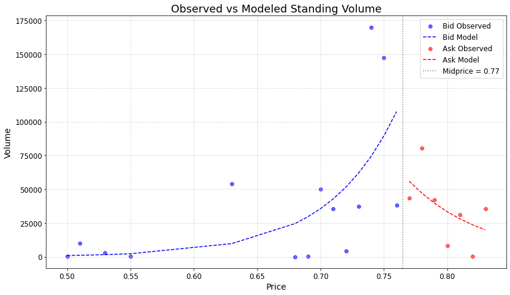

```python
import matplotlib.pyplot as plt

# Create the plot
fig, ax = plt.subplots(figsize=(12, 7), facecolor='white')

# Plot observed and modeled volume by side
for side, color in [('bid', 'blue'), ('ask', 'red')]:
    subset = plots[plots['Side'] == side].sort_values(by='Price')
    ax.scatter(subset['Price'], subset['Size'], label=f'{side.capitalize()} Observed', alpha=0.6, color=color)
    ax.plot(subset['Price'], subset['ModelMean'], label=f'{side.capitalize()} Model', linestyle='--', color=color)

# Midprice line
ax.axvline(midprice, color='gray', linestyle=':', label=f'Midprice = {midprice:.2f}')

# Styling
ax.set_title("Observed vs Modeled Standing Volume", fontsize=18)
ax.set_xlabel("Price", fontsize=14)
ax.set_ylabel("Volume", fontsize=14)
ax.legend(fontsize=12)
ax.grid(True, linestyle=':')
ax.tick_params(labelsize=12)

plt.tight_layout()
plt.show()
```